# Discovery Platform Overview

How the single-screen discovery platform is laid out

The discovery platform works on one screen: you build a query, run it, and triage the results in the same view. This page covers the layout and how its panels connect.

## Layout

The screen has a top strip and two working columns: results on the left, detail on the right.

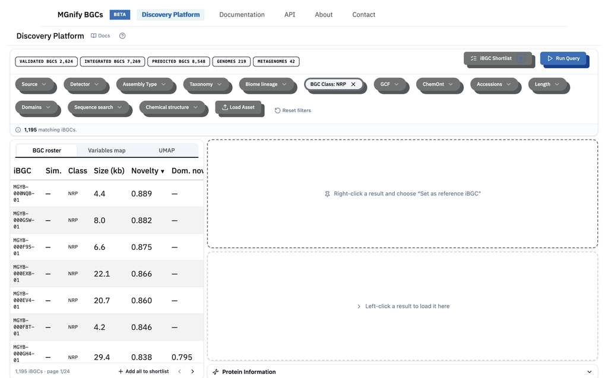

Top strip with the filter chips and Run Query; the results panel (left) with its three tabs; and the stacked detail panels (right).

### Results panel (left)

One panel, three tabs over the same result set:

- **BGC roster** — a sortable table, one row per iBGC.
- **Variables map** — a scatter plot of any two metrics you choose.
- **UMAP** — a 2-D map where similar iBGCs cluster together.

Switching tabs does not change which iBGCs are shown — only how they’re displayed.

### Detail panels (right)

Two iBGC detail cards stacked above a protein panel:

- **Reference** (top) — the iBGC you pin to compare others against.
- **Compare** (middle) — updates each time you left-click a result.
- **Protein Information** (bottom, collapsible) — the gene you last clicked, with its domain annotations and sequence.

Both detail cards share the same layout; see iBGC Detail.

## The core interactions

The discovery platform is driven by clicks on iBGCs, whether in the roster or on a map:

| Action | Result |
| --- | --- |
| **Left-click** an iBGC | Loads it into the **Compare** panel |
| **Right-click → Set as reference iBGC** | Pins it to the **Reference** panel |
| **Right-click → Find similar iBGCs** | Runs a similarity search around it |
| **Right-click → Add to shortlist** | Adds it to your shortlist |
| **Click a gene (CDS)** in a detail card | Loads its protein into the **Protein Information** panel |

The reference stays pinned while you left-click through other candidates, so you can compare many iBGCs against one anchor.

## Nothing loads until you Run Query

The result panels stay empty until you press **Run Query**. This lets you assemble a complete query — several filters, perhaps an advanced search chip — before anything is fetched. The badges in the top strip always reflect the full catalogue, not your current filters; the match count appears in a banner after you run.

## Result caps and sampling

A query can match more iBGCs than the maps can plot at once. When the result set exceeds the display cap, the maps show a representative sample and the banner reports the true total. Narrow the filters to see every match, or work from your shortlist — the report export uses the iBGCs you selected, not the sampled view.

## Related pages

- BGC Roster · Variables Map · UMAP
- iBGC Detail · Protein Panel
- Filtering · Search Overview